# Public Transport Winterbottlenecks

[Public GitHub Repository](https://github.com/paACode/publictransport_winterbottlenecks_palest)

Leonard Dost, Stefan Dreyfus, Pascal Ackermann

01.06.2025

# Introduction

Zentralbahn, a regional railway company, identified a pressing need to improve the overall performance of its train operations. In response, the company initiated a comprehensive, data-driven investigation aimed at uncovering operational inefficiencies and ensuring long-term service reliability.

As part of this initiative, Zentralbahn engaged an external data science consultant to analyze publicly available OpenTransportData. The consultant’s initial findings revealed a noticeable performance bottleneck in November 2024, likely linked to seasonal, winter-related disruptions.

Although Zentralbahn already had an internal hypothesis regarding the cause, the company is committed to an open, evidence-based approach and is seeking independent confirmation and fresh insights. To broaden the analytical perspective, Zentralbahn partnered with the Hochschule Luzern (HSLU) to carry out a dedicated project using operational data from November 2024.

# Project Goals

**1. Identifying Root Causes of Performance Bottlenecks**

The primary objective is to analyze train operations during **November 2024** to:

- Validate Zentralbahn’s internal assumptions about winter-related disruptions,
- Identify underlying patterns or unexpected factors contributing to performance bottlenecks,
- Provide data-driven recommendations for improving punctuality and operational efficiency on affected lines.

**2. Improving Data Quality Through Predictive Modeling**

A secondary goal is to address known data quality issues in Zentralbahn’s internal datasets. Specifically, several records contain **missing or incorrect train station entries**. HSLU is tasked with:

- Investigating the **November 2024 dataset**, which is considered consistent and reliable,
- Exploring the potential to **predict or classify missing train station values** using available variables such as timestamps, route IDs, or event sequences,
- Developing a methodology that could later be applied to **recover and correct corrupted historical datasets**.

# Report Structure

To ensure a thorough and methodical exploration of different modeling approaches, responsibilities for leading the development of individual models were distributed among the team members. The allocation of model leadership was as follows:

Leonard Dost: Linear Model, Support Vector Machine

Pascal Ackermann: Generalised Linear Model (Poisson family), Neural Network

Stefan Dreyfus: Generalised Additive Model, Generalised Linear Model (Binomial family)

While each team member took the lead on specific models, the entire team contributed actively to all stages of the project. From data preprocessing to model evaluation and interpretation, the collaborative approach ensured consistency, knowledge sharing, and a stronger overall outcome.

The data set has 91’271 entries which fulfills the requirement of the assessment. On the one hand, data set contained already a wide range of data types. On the other hand, we had to add further columns in order to fullfil the requirement. The data set has the following data types:

**Categorical:** `BETRIEBSTAG`, `LINIEN_TEXT`, `HALTESTELLEN_NAME`, `START`, `ZIEL`, `DELAY_Category`, `TAGESZEIT`, `RUSH_HOUR`  
**Datetime:** `ANKUNFTSZEIT`, `AN_PROGNOSSE`, `ABFAHRTZEIT`, `AB_PROGNOSSE`  
**Continuous:** `ANKUNFTDELAY_sec`, `ABFAHRTDELAY_sec`, `w_precip_mm_Luzern`, `w_temp_min_c_Luzern`, `w_temp_avg_c_Luzern`  
**Binary:** `FAELLT_AUS_TF`

While the table summarizes the original data types, some variables are adapted for specific models. `ANKUNFTDELAY_sec` and `ABFAHRTDELAY_sec`, though continuous, are treated as count data in the corresponding chapter where the model requires it. These variables are easily convertible by focusing solely on positive delay values and ignoring early arrivals or departures.

Similarly, `DELAY_Category` is transformed into a binomial variable for binary classification tasks.

All public transport data used in this project was obtained from [OpenTransportData](https://archive.opentransportdata.swiss/actual_data_archive.htm), which provides official, high-resolution datasets on public transportation in Switzerland. Weather-related data was sourced from [Swiss Federal Geoportal](https://data.geo.admin.ch), offering location-specific historical weather records relevant to the operational context.

The following chapters present different approaches to modeling. The analysis begins with a general approach, using an initial artificial neural network (ANN) without extensive knowledge of the data. It then progresses toward more granular and detailed models. In the final chapter, the insights gained throughout the analysis are consolidated and integrated into a comprehensive model.

# A First Look: Artificial Neural Network

This chapter investigates the predictability of train cancellations without performing prior exploratory data analysis (EDA). It serves as an initial attempt to understand the underlying data. More detailed analyses using simpler and more interpretable models will follow in subsequent chapters.

An artificial neural network (ANN) enables the construction of a predictive model without requiring extensive knowledge of the data structure. It can provide early indications of whether the data contains a meaningful signal.

Therefore, the approach directly attempts to predict whether a train is cancelled, using all available variables, except those that explicitly reveal cancellation status. These are:

- `AN_PROGNOSE` and `AB_PROGNOSE`: Always `NA` when a train is cancelled
- All derived columns such as:
  - `ABFAHRTDELAY_sec`,
  - `ANKUNFTDELAY_sec`,
  - `RUSH_HOUR`, `TAGESZEIT`, `DELAY_CATEGORY`
  - `ZIEL`, `START`

These variables are excluded to avoid data leakage.

## Data Preparation

As a first step, the distribution of the response variable is examined. An initial analysis indicates that 21% of the trains in the dataset are cancelled. This was taken into account during data preparation. For the ANN to work, the following steps were performed:

1. Convert character and logical variables to factors
2. Remove factors with fewer than two levels (contain no information)
3. Use only factor variables to keep the ANN simple
4. Drop time columns because they include a large number of levels
5. Perform one-hot encoding
6. Stratify train and test data
7. Downsample train data to ensure an equal number of cancelled and uncancelled trains

## Building the Network

Building the Network included a lot of trial and error. Because for many configurations the model did not converge. In the end 3 predictors could be found which lead to quite good prediction:

- BETRIEBSTAG
- LINIEN_TEXT
- HALTESTELLEN_NAME

## Results

The model successfully predicts train cancellations using only three categorical predictors: **BETRIEBSTAG**, **LINIEN_TEXT**, and **HALTESTELLEN_NAME**. Despite the test data containing 80% uncancelled and 20% cancelled trains, the model performs well thanks to stratification and downsampling during training.

These findings highlight that these predictors are valuable features and warrant further exploration through more detailed modeling and analysis.

```
Confusion Matrix and Statistics

          Reference
Prediction FALSE  TRUE
     FALSE 14251   170
     TRUE    239  3593

               Accuracy : 0.9776
                 95% CI : (0.9753, 0.9797)
    No Information Rate : 0.7938
    P-Value [Acc > NIR] : < 2.2e-16

                  Kappa : 0.932

 Mcnemar's Test P-Value : 0.0007727

            Sensitivity : 0.9835
            Specificity : 0.9548
         Pos Pred Value : 0.9882
         Neg Pred Value : 0.9376
             Prevalence : 0.7938
         Detection Rate : 0.7807
   Detection Prevalence : 0.7901
      Balanced Accuracy : 0.9692

       'Positive' Class : FALSE
```

# Linear Model

To explore whether the Zentralbahn railway system incorporates buffer times into its scheduling, we examine the relationship between **arrival delays** and subsequent **departure delays**. The core question: *If a train arrives late, does it depart late as well* –*or does the schedule absorb the delay?* A slope of 1 in a delay-to-delay model would indicate full propagation, while a slope below 1 would suggest some level of built-in buffer or recovery.

Understanding this relationship is key to improving operational robustness. Our modeling strategy starts with a simple baseline and evolves to include external (e.g. weather) and operational (e.g. rush hour, hub status) factors. We also apply log-transformations to normalize the right-skewed distribution of delay times, improving interpretability and model fit.

## Data Preparation

We begin by filtering the data to focus only on meaningful delay values, excluding negative delays which represent early arrivals or departures. These are operationally different phenomena and can distort the regression analysis.

We then transform the delay variables using a log transformation to account for the right-skewed distribution. Precipitation is also log-transformed due to its zero-inflated and skewed nature.

## Step 1: Baseline Log-Log Model

We first fit a simple model with only the arrival delay as a predictor. The goal is to assess the pure propagation effect, without confounding from other variables.

```
Call:
lm(formula = log_departure ~ log_arrival, data = d.trains_filtered)

Residuals:
    Min      1Q  Median      3Q     Max
-4.5931  0.0639  0.1348  0.1793  0.3757

Coefficients:
            Estimate Std. Error t value Pr(>|t|)
(Intercept) 0.105049   0.009471   11.09   <2e-16 ***
log_arrival 0.935824   0.002333  401.12   <2e-16 ***
---
Signif. codes:  0 '***' 0.001 '**' 0.01 '*' 0.05 '.' 0.1 ' ' 1

Residual standard error: 0.4796 on 31940 degrees of freedom
Multiple R-squared:  0.8344,    Adjusted R-squared:  0.8344
F-statistic: 1.609e+05 on 1 and 31940 DF,  p-value: < 2.2e-16
```

### Interpretation

Although delays are recorded in whole seconds, they reflect an underlying continuous process. To better model this, we applied a log transformation to reduce skewness and improve fit. While the transformation changes the scale, it enables a meaningful interpretation in terms of relative (percentage-based) changes.

From the `summary()` output of our baseline model:

- **Slope (`log_arrival` ≈ 0.936)**: A 1% increase in arrival delay is associated with an approximate 0.94% increase in departure delay - indicating a strong, nearly proportional relationship.
- **Intercept (~0.105)**: After back-transforming, this corresponds to a **baseline multiplier of ~1.111**, meaning when arrival delay is 1 minute, expected departure delay is about **1.11 minutes**.
- **R-squared (≈ 0.834)**: About 83% of the variation in log departure delay is explained by log arrival delay alone.
- **Statistical significance**: The extremely low p-value for log_arrival (< 2e-16) provides strong evidence that arrival delay affects departure delay. We can reject the hypothesis that arrival delay has no effect.

The following plot visually confirms the strength of the relationship:

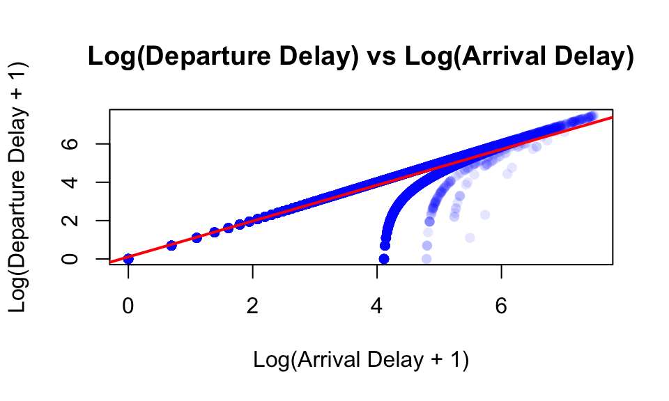

Most observations cluster tightly around the fitted line, reinforcing that **arrival delay is a highly predictive factor** for departure delay, with minimal evidence of buffering in the current system.

## Step 2: Including Environmental and Temporal Context

Next, we add external predictors – **log-transformed precipitation**, **temperature**, and **rush hour categories** – to see if delay propagation is influenced by weather or time of day.

```
Call:
lm(formula = log_departure ~ log_arrival + log_rain + w_temp_avg_c_Luzern +
    RUSH_HOUR, data = d.trains_filtered)

Residuals:
    Min      1Q  Median      3Q     Max
-4.5837  0.0618  0.1345  0.1794  0.3792

Coefficients:
                               Estimate Std. Error t value Pr(>|t|)
(Intercept)                   0.1055421  0.0110233   9.574   <2e-16 ***
log_arrival                   0.9363244  0.0023560 397.429   <2e-16 ***
log_rain                      0.0013045  0.0013616   0.958   0.3381
w_temp_avg_c_Luzern           0.0004911  0.0009534   0.515   0.6065
RUSH_HOURrush_hour_abend     -0.0173420  0.0083247  -2.083   0.0372 *
RUSH_HOURrush_hour_vormittag -0.0086933  0.0072063  -1.206   0.2277
---
Signif. codes:  0 '***' 0.001 '**' 0.01 '*' 0.05 '.' 0.1 ' ' 1

Residual standard error: 0.4796 on 31936 degrees of freedom
Multiple R-squared:  0.8344,    Adjusted R-squared:  0.8344
F-statistic: 3.218e+04 on 5 and 31936 DF,  p-value: < 2.2e-16
```

### Interpretation

- `log_arrival` remains the dominant predictor, with a coefficient of approximately 0.936. This means that a **1% increase in arrival delay leads to an estimated 0.94% increase in departure delay** — a strong, nearly proportional relationship. The p-value (p < 2e-16) provides **strong evidence** for this effect.
- Rainfall and temperature have **no statistically significant effect**, as their p-values are far above conventional thresholds (p > 0.3). We **fail to reject** the null hypothesis that they influence delay propagation.
- There is **moderate evidence** that the **evening rush hour** slightly reduces delay propagation. The coefficient of -0.017 (p = 0.037) corresponds to an estimated **1.7% reduction in departure delay**, relative to non-rush hours. The morning peak shows no significant effect.

This suggests that delay propagation is robust across most conditions, but slightly more resilient during the evening.

The following plot illustrates the residuals of the extended model:

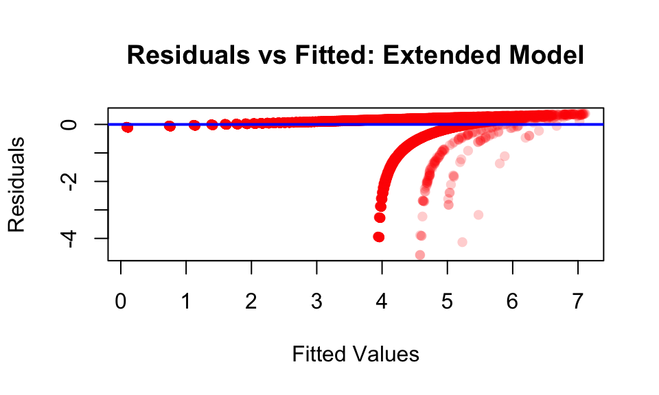

While the residuals vs. fitted plot shows some banding and slight curvature – particularly for higher fitted values – this is expected due to the log transformation of discrete delay values. The absence of a clear funnel or strong pattern suggests that the model is reasonably well-specified, though minor heteroscedasticity may still be present. This observation could motivate future exploration of **non-linear models** or those that account for **changing variance**, such as generalized additive models (GAMs) or quantile regression.

## Step 3: Analyzing Luzern as a Major Hub

Finally, we test whether Luzern’s role as a major start or end station affects the delay propagation dynamics. We include binary indicators for whether a train **starts** or **ends** in Luzern.

```
Call:
lm(formula = log_departure ~ log_arrival + log_rain + w_temp_avg_c_Luzern +
    start_in_Luzern + ziel_in_Luzern, data = d.trains_filtered)

Residuals:
    Min      1Q  Median      3Q     Max
-4.5807  0.0535  0.1341  0.1833  0.3832

Coefficients:
                        Estimate Std. Error t value Pr(>|t|)
(Intercept)            0.2261584  0.0156105  14.488   <2e-16 ***
log_arrival            0.9347041  0.0023454 398.525   <2e-16 ***
log_rain               0.0011750  0.0013590   0.865    0.387
w_temp_avg_c_Luzern    0.0003911  0.0009515   0.411    0.681
start_in_LuzernLuzern -0.1182824  0.0115390 -10.251   <2e-16 ***
ziel_in_LuzernLuzern  -0.1326095  0.0115610 -11.470   <2e-16 ***
---
Signif. codes:  0 '***' 0.001 '**' 0.01 '*' 0.05 '.' 0.1 ' ' 1

Residual standard error: 0.4786 on 31936 degrees of freedom
Multiple R-squared:  0.8351,    Adjusted R-squared:  0.835
F-statistic: 3.233e+04 on 5 and 31936 DF,  p-value: < 2.2e-16
```

### Interpretation

- `log_arrival` remains the **primary driver of departure delay**, with a coefficient of ~0.935. This means that a **1% increase in arrival delay corresponds to an estimated 0.94% increase in departure delay** — reaffirming the near-proportional delay propagation observed in earlier models. The effect is highly significant (p < 2e-16).
- Rainfall and temperature continue to show **no statistically significant** effect (p > 0.3), and we **fail to reject** the hypothesis that they influence delay propagation.
- The inclusion of station context provides new insight:
  - Trains that **start in Luzern** show a coefficient of -0.118, which translates to a **~11.2% lower departure delay** relative to other stations (exp(-0.118) ≈ 0.888).
  - Trains that **end in Luzern** show a coefficient of -0.133, corresponding to a **~12.5% reduction in delay** (exp(-0.133) ≈ 0.875).

The residual plot below shows the model’s prediction consistency:

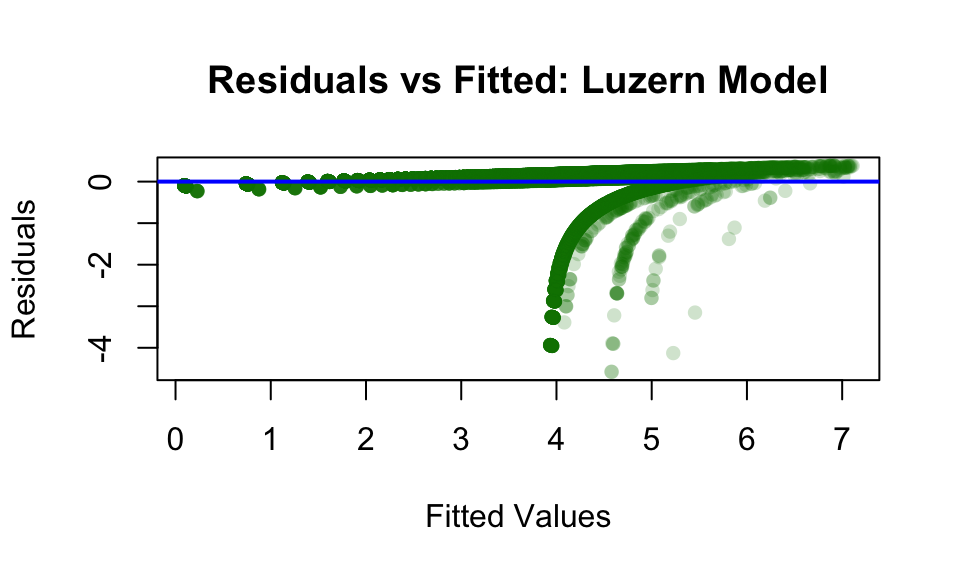

## Conclusion

A limitation of this analysis lies in the **mismatch between data resolutions**: train delays are recorded at the stop level, while weather data is only available as **daily averages**. As a result, short-term or location-specific weather effects may be underestimated.

Nonetheless, our models consistently show that **arrival delays are the dominant driver of departure delays**, with an estimated **elasticity of ~0.94**. This implies that a **1% increase in arrival delay leads to a ~0.94% increase in departure delay**, indicating **near-complete delay propagation**.

Rainfall and temperature show **no statistically significant effect** on delay propagation. In contrast, trains **starting or ending in Luzern** experience **~11–13% lower departure delays**, suggesting that Luzern functions as a **stabilizing hub**, likely due to infrastructure or recovery capacity.

These insights suggest that operational improvements should focus on **non-hub stations**, where delay propagation is more pronounced. Targeted increases in buffer time or recovery resources at these locations may yield the greatest reductions in network-wide disruptions.

# Generalised Additive Model

In this project, we apply Generalized Additive Models (GAMs) to analyze the effects of various predictors on train delays, specifically focusing on the response variables ANKUNFTDELAY_min (arrival delay in minutes) and ABFAHRTDELAY_min (departure delay in minutes). Due to the limited availability of continuous variables in our dataset these two delay metrics will be the response variables we will focus on. A key subset of our predictors is related to weather conditions. However, because the Zentralbahn railway line spans multiple climatic regions, comparing weather-related predictors across all stations introduces variability that may obscure meaningful patterns. To address this, we restrict our analysis to a subset of stations located within the Lucerne region, where the climate is more uniform.

R assumes for GAM models the Gaussian family for the response variables. Therefore, let’s have a look if the response variables ANKUNFTDELAY_min and ABFAHRTDELAY_min are Gaussian distributed.

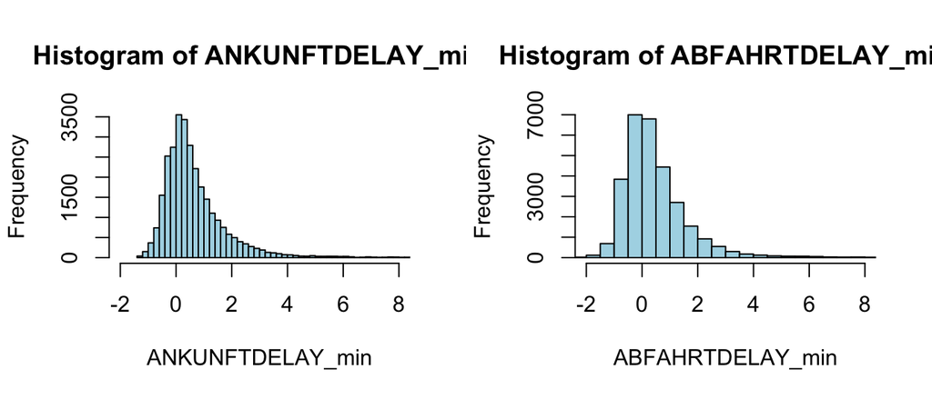

We see that both response variables are not normally distributed. In real-world train operations, early arrivals or departures are relatively uncommon compared to delays. Moreover, the distribution indicates that longer delays occur less frequently than shorter ones, reflecting typical delay patterns observed in Swiss public transportation. For this reason, we restrict our dataset for the GAM analysis to observations with delays between -2 and +4 minutes, aiming to ensure a distribution that more closely approximates the Gaussian assumption required by the model.

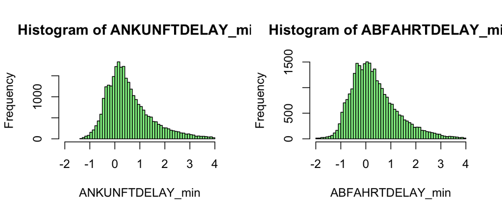

As a first step, we will explore how the average temperature in Lucerne affects arrival delays of trains.

```
Family: gaussian
Link function: identity

Formula:
ANKUNFTDELAY_min ~ s(w_temp_avg_c_Luzern)

Parametric coefficients:
            Estimate Std. Error t value Pr(>|t|)
(Intercept)  0.56586    0.00519     109   <2e-16 ***
---
Signif. codes:  0 '***' 0.001 '**' 0.01 '*' 0.05 '.' 0.1 ' ' 1

Approximate significance of smooth terms:
                         edf Ref.df   F p-value
s(w_temp_avg_c_Luzern) 8.881  8.995 122  <2e-16 ***
---
Signif. codes:  0 '***' 0.001 '**' 0.01 '*' 0.05 '.' 0.1 ' ' 1

R-sq.(adj) =  0.0364   Deviance explained = 3.67%
GCV = 0.78087  Scale est. = 0.7806    n = 28984
```

The p-value associated with the smooth term is close to zero, providing strong evidence that the average temperature in Lucerne has a statistically significant effect on arrival delays. The estimated effective degrees of freedom (edf ≈ 9) suggest a moderately complex, non-linear relationship. However, the adjusted R-squared value of 0.036 and the explained deviance of only 3.67% indicate that the model captures only a small portion of the variation in arrival delays. Thus, while the effect is significant, temperature alone does not explain much of the delay variability.

This is why will proceed with a more detailed analysis and explore how time of day, train lines, average temperature and precipitation affect departure delays of trains.

Interpretation of Parametric Coefficients:

```
Family: gaussian
Link function: identity

Formula:
ABFAHRTDELAY_min ~ TAGESZEIT + LINIEN_TEXT + s(w_temp_avg_c_Luzern) +
    s(w_precip_mm_Luzern)

Parametric coefficients:
                    Estimate Std. Error t value Pr(>|t|)
(Intercept)          1.24747    0.33220   3.755 0.000174 ***
TAGESZEITMittag     -0.30000    0.01880 -15.961  < 2e-16 ***
TAGESZEITNachmittag -0.16098    0.01854  -8.682  < 2e-16 ***
TAGESZEITNacht      -0.30080    0.01631 -18.441  < 2e-16 ***
TAGESZEITVormittag  -0.11592    0.01655  -7.002 2.57e-12 ***
LINIEN_TEXTIR       -0.22497    0.33290  -0.676 0.499183
LINIEN_TEXTPE       -2.32029    0.93772  -2.474 0.013352 *
LINIEN_TEXTS4       -0.83845    0.33198  -2.526 0.011555 *
LINIEN_TEXTS41      -1.35328    0.33415  -4.050 5.14e-05 ***
LINIEN_TEXTS44      -1.04235    0.33382  -3.122 0.001795 **
LINIEN_TEXTS5       -0.50933    0.33200  -1.534 0.125008
LINIEN_TEXTS55      -1.95525    0.33936  -5.762 8.41e-09 ***
---
Signif. codes:  0 '***' 0.001 '**' 0.01 '*' 0.05 '.' 0.1 ' ' 1

Approximate significance of smooth terms:
                         edf Ref.df     F p-value
s(w_temp_avg_c_Luzern) 9.000  9.000 79.03  <2e-16 ***
s(w_precip_mm_Luzern)  8.319  8.591 59.29  <2e-16 ***
---
Signif. codes:  0 '***' 0.001 '**' 0.01 '*' 0.05 '.' 0.1 ' ' 1

R-sq.(adj) =  0.119   Deviance explained = 11.9%
GCV = 0.76993  Scale est. = 0.76915   n = 28984
```

The reference levels for the categorical predictors are evening for TAGESZEIT and EXT for LINIEN_TEXT. Under these baseline conditions (evening, 0°C, and 0 mm precipitation), the EXT line of Zentralbahn in the Lucerne region has an average departure delay of approximately 1.25 minutes.

The time of day has a statistically significant effect on departure delays. Compared to the evening (the reference category), trains departing at other times of day experience between 0.12 and 0.30 minutes less delay on average. These differences are highly significant, as indicated by the very small p-values (all p < 0.0001), suggesting strong evidence that delays vary by time of day.

Regarding train lines, the IR line shows a reduction of 0.22 minutes compared to EXT, although this difference is not statistically significant (p = 0.5). In contrast, the PE line exhibits the largest reduction, with trains experiencing on average 2.32 minutes less delay than EXT, a difference that is statistically significant. Likewise, the S4, S41, S44, and S55 lines show significantly reduced delays compared to EXT, with reductions of 0.84, 1.35, 1.04, and 1.96 minutes, respectively. The S5 line’s difference (0.51 minutes less) is not statistically significant.

Interpretation of the Smooth Terms:

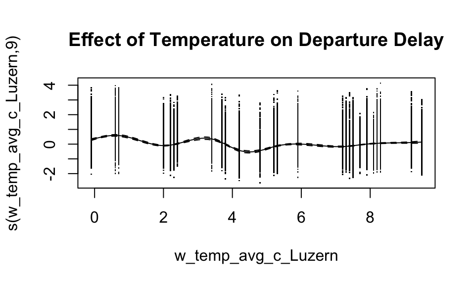

The smooth term for average temperature has an estimated effective degrees of freedom (edf) of approximately 9, indicating a moderately complex non-linear relationship with departure delay. We have strong evidence that it is not 0 with a p-value < 0.05. The corresponding plot reveals that temperatures between 0 and 6°C have a stronger effect on departure delay, whereas between roughly 6–7°C and 8–10°C the effect is minimal.

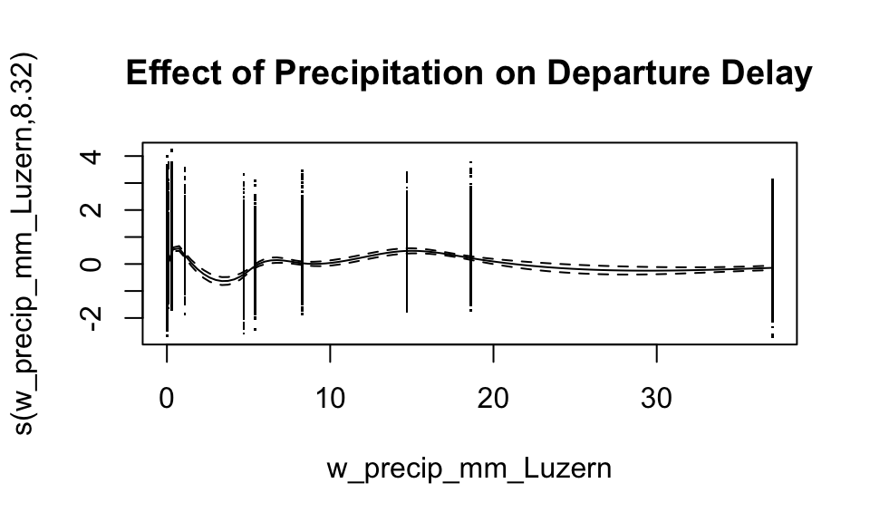

Similarly, the smooth term for average precipitation (w_precip_mm_Luzern) has an edf of about 8.32, suggesting a moderately complex non-linear relationship. We have strong evidence that it is not 0 with a p-value < 0.05.

Overall model performance:

The adjusted R² value of 0.119 means that the model explains around 11.9% of the variation in departure delays. This suggests that the predictors included in the model have a measurable effect on delays, but a large part of the variation (around 88%) is still not accounted for. This can be considered as not unusual in real-world transportation data, where many factors that influence delays—such as technical problems, temporary disruptions, staffing issues or operational decisions—are not included in the dataset. While the model successfully identifies several statistically significant predictors, it also shows that more variables or more complex modeling approaches might be needed to better capture all the factors that contribute to departure delays.

Conclusion:

GAM analysis revealed that weather factors significantly impact train delays in the Lucerne region, aligning with the project’s goal to understand winter-related disruptions in November. However, the models capture only a small portion of the variability, suggesting further investigation is needed to fully explain performance bottlenecks.

# Generalised Linear Model with family set to Binomial

To further investigate the factors influencing train delays on the Zentralbahn network, a Generalized Linear Model (GLM) with a binomial family is applied. This model aims to predict the likelihood of a train being delayed based on key operational variables, including train line and rush hour status. By classifying delays as a binary outcome, the analysis provides deeper insights into line-specific vulnerabilities and the broader operational challenges faced during peak travel times. This contributes to the project’s overarching goal of identifying root causes of performance bottlenecks and improving punctuality through data-driven strategies.

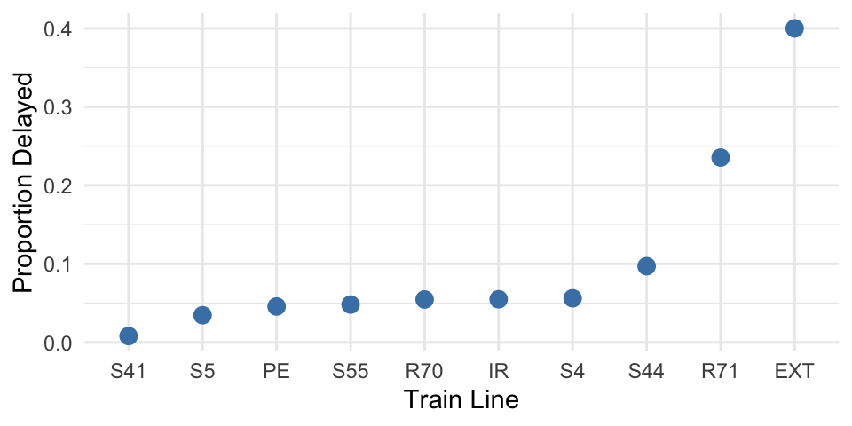

In this plot, we can see that the EXT line has the highest proportion of delayed trains, with approximately 40% of its services experiencing delays. The line with the second highest delay rate is the R71, where around 24% of trains are delayed. On the other end of the spectrum, the S41 line shows the lowest delay rate, with only about 1% of its trains being delayed.

To predict whether a train is delayed, we use a binomial GLM with Train_Delayed as the binary response variable and LINIEN_TEXT (train line) as the predictor. This model estimates how the probability of delay varies across different train lines.

```
Call:
glm(formula = Train_Delayed ~ LINIEN_TEXT, family = "binomial",
    data = zb_final_binominal)

Coefficients:
               Estimate Std. Error z value Pr(>|z|)
(Intercept)     -0.4055     0.6455  -0.628 0.529910
LINIEN_TEXTIR   -2.4388     0.6489  -3.758 0.000171 ***
LINIEN_TEXTPE   -2.6321     0.6482  -4.061 4.90e-05 ***
LINIEN_TEXTR70  -2.4442     0.6551  -3.731 0.000191 ***
LINIEN_TEXTR71  -0.7723     0.6514  -1.186 0.235811
LINIEN_TEXTS4   -2.4151     0.6464  -3.736 0.000187 ***
LINIEN_TEXTS41  -4.4067     0.8177  -5.389 7.09e-08 ***
LINIEN_TEXTS44  -1.8249     0.6584  -2.772 0.005574 **
LINIEN_TEXTS5   -2.9234     0.6464  -4.523 6.11e-06 ***
LINIEN_TEXTS55  -2.5777     0.6704  -3.845 0.000121 ***
---
Signif. codes:  0 '***' 0.001 '**' 0.01 '*' 0.05 '.' 0.1 ' ' 1

(Dispersion parameter for binomial family taken to be 1)

    Null deviance: 21880  on 57218  degrees of freedom
Residual deviance: 21375  on 57209  degrees of freedom
AIC: 21395

Number of Fisher Scoring iterations: 7
```

The number of Fisher Scoring iterations is 7, which is an acceptable value. The dispersion parameter in the model was calculated by dividing the residual deviance (21375) by the residual degrees of freedom (57209), yielding a value of 0.374. This value, being less than 1, indicates that there is no overdispersion in the data. Therefore, the binomial logistic regression is an appropriate fit for the dataset, and no adjustments for overdispersion are necessary.

On one hand, the p-values for almost all the train lines are very small, indicating that the train lines have a statistically significant effect on whether a train is delayed or not. Since the coefficients for the train lines are negative, it suggests that the different train lines have a lower likeliness of being delayed compared to the baseline train line.

On the other hand, the train line R71, which operates between Meiringen and Innertkirchen, has a p-value above 0.05. This suggests that R71 does not have a statistically significant impact on whether a train is delayed or not. This is interesting because, when the predictors were plotted, R71 was the line with the second-highest probability of delay, with an average delay of around 24%. The reason for this contradiction could be that while the R71 line might often experience delays, the variance of the delays might be quite narrow. To explore this, let’s take a look at the boxplot of the train delays by line.

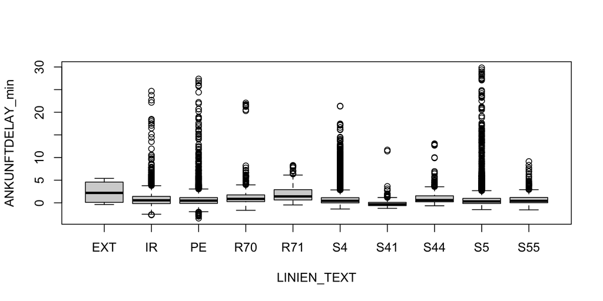

In the boxplot, we can see that the R71 has a relatively large variance between the 25th and 75th percentiles of the data. Nevertheless, R71 has fewer outliers compared to the other lines. The delays on R71 might be consistent but not extreme enough to be detected as a significant predictor in the GLM.

Although R71 has a relatively high average delay, this does not necessarily imply that the line itself is a major factor in predicting delays. The GLM is trying to predict the probability of a delay (yes/no) based on various predictors. Other variables—such as weather, time of day, or operational factors—might influence whether a delay occurs for R71 trains.

Lets have now a look at the coefficients of glm_delay

```
   (Intercept)  LINIEN_TEXTIR  LINIEN_TEXTPE LINIEN_TEXTR70 LINIEN_TEXTR71
          0.67           0.09           0.07           0.09           0.46
 LINIEN_TEXTS4 LINIEN_TEXTS41 LINIEN_TEXTS44  LINIEN_TEXTS5 LINIEN_TEXTS55
          0.09           0.01           0.16           0.05           0.08
```

As a next step, we simulate predictions using the GLM to estimate the likelihood of train delays, and then compare these simulated results with the actual dataset. We will have first a look at the mean of the simulated results:

```
[1] 0.1045912
```

The mean of the simulated data is 0.105. This is the reason why we cannot take a threshold of 0.5. This would result in nearly all cases being classified as non-delayed, since very few predicted probabilities exceed 0.5—ultimately leading to extremely poor sensitivity and almost no true positives.

```
Confusion Matrix and Statistics

          Reference
Prediction     0     1
         0 43493  2175
         1 11006   545

               Accuracy : 0.7696
                 95% CI : (0.7662, 0.7731)
    No Information Rate : 0.9525
    P-Value [Acc > NIR] : 1

                  Kappa : -6e-04

 Mcnemar's Test P-Value : <2e-16

            Sensitivity : 0.79805
            Specificity : 0.20037
         Pos Pred Value : 0.95237
         Neg Pred Value : 0.04718
             Prevalence : 0.95246
         Detection Rate : 0.76011
   Detection Prevalence : 0.79813
      Balanced Accuracy : 0.49921

       'Positive' Class : 0
```

The model’s accuracy is 76.96%, which at first glance suggests decent performance, but this metric is heavily influenced by the significant imbalance between delayed and non-delayed trains in the dataset. Due to the high punctuality of Swiss trains, the vast majority of observations are non-delays, making accuracy a somewhat misleading indicator of model effectiveness.

Balanced accuracy, which considers both sensitivity and specificity, is 49.9% suggesting the model performs no better than random guessing when it comes to balancing delay and non-delay predictions.

# Poisson Model

## Overview

Since the response variable is a count-variable, we expect it to exhibit right skewness and increasing variance as the count increases.

Plotting the data reveals that indeed the count-variable is right-skewed.

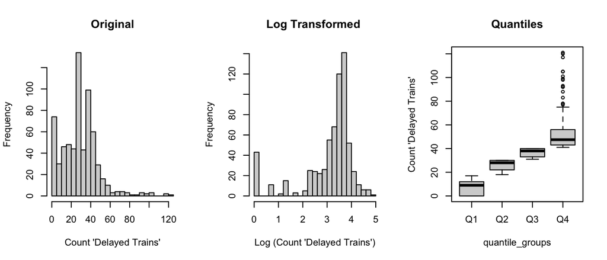

The quartile boxplot does not support the assumption that the variance increases linearly with the mean. This suggests that the count variable may not follow a Poisson distribution. This is an initial indication that the GLM should be fitted with a quasipoisson family to account for overdispersion.

## Finding reasonable Predictors

### Operation Category”

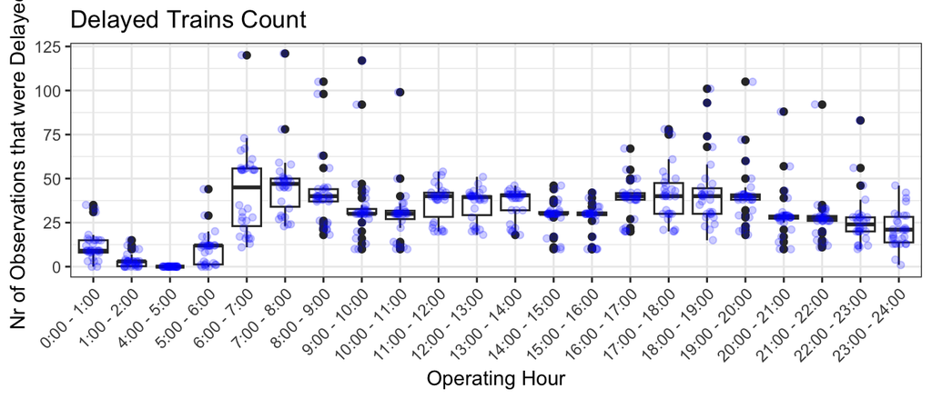

Indeed there seems to be a pattern in “operation hour”. In a first step, the “operation- hour” is simplified by “operation category” with 3 levels:

- Low Operation : (0:00 until 6:00)
- Rush Hour : (6:00 until 9:00) and (11:00 until 14:00) and (16:00 until 20:00)
- Normal Operation : Everything else

The boxplot on the left compares the number of delayed trains across operation categories, but this comparison is not meaningful because each category has a different total number of train arrivals. On the right, the delay counts are normalized by the total number of trains in each category. As a result, the differences between the boxplots become less pronounced but more interpretable

```
# A tibble: 3 × 2
  operation_category count
  <chr>              <int>
1 Low Operation       2841
2 Normal Operation   32718
3 Rush Hour          45515
```

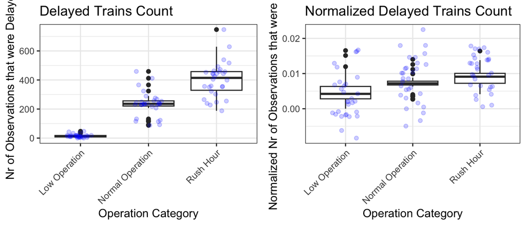

We now perform an ANOVA followed by multiple comparison testing to statistically assess the differences observed in the normalized boxplot.

- ANOVA confirms that there is a statistically significant difference between at least one of the three operation categories.
- The multiple comparison test reveals that not all pairwise differences are significant. While ‘Low Operation’ differs significantly from both ‘Normal Operation’ and ‘Rush Hour’, the difference between ‘Normal Operation’ and ‘Rush Hour’ is not statistically significant.

This supports our earlier observation from the boxplot and confirms that the predictor is overall significant, though not all categories differ from each other

```
                   Df    Sum Sq   Mean Sq F value   Pr(>F)
operation_category  2 0.0001913 9.566e-05   9.649 0.000164 ***
Residuals          87 0.0008625 9.910e-06
---
Signif. codes:  0 '***' 0.001 '**' 0.01 '*' 0.05 '.' 0.1 ' ' 1
```

```
     Simultaneous Tests for General Linear Hypotheses

Multiple Comparisons of Means: Tukey Contrasts


Fit: aov(formula = Count_Delayed_Norm ~ operation_category, data = d.poisson.agg.day.oc)

Linear Hypotheses:
                                      Estimate Std. Error t value Pr(>|t|)
Normal Operation - Low Operation == 0 0.001947   0.000813   2.394   0.0488 *
Rush Hour - Low Operation == 0        0.003566   0.000813   4.387   <1e-04 ***
Rush Hour - Normal Operation == 0     0.001620   0.000813   1.992   0.1201
---
Signif. codes:  0 '***' 0.001 '**' 0.01 '*' 0.05 '.' 0.1 ' ' 1
(Adjusted p values reported -- single-step method)
```

To conclude, the analysis has revealed a valuable predictor that will be utilized in the subsequent modeling phase

### “Event Category”

Creating a level for each Day in November does not make sense. Therefore data are again visualized to see if there are any patterns so that predictor can be simplified. In the boxplot there are 22 observation per “operation day”. One obsevation per operating hour.

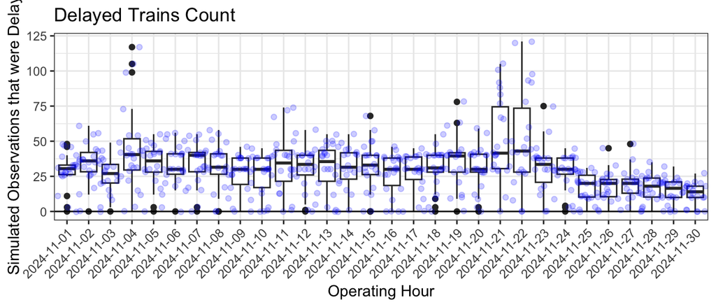

The boxplot on the left compares the number of delayed trains across event categories, but this comparison is not meaningful because each category has a different total number of train arrivals. On the right, the delay counts are normalized by the total number of trains in each category. As a result, the differences between the boxplots become less pronounced but more interpretable

```
# A tibble: 3 × 2
  event_category     count
  <chr>              <int>
1 Extreme Days        5515
2 Meiringen Reopened 16323
3 Normal Operation   59236
```

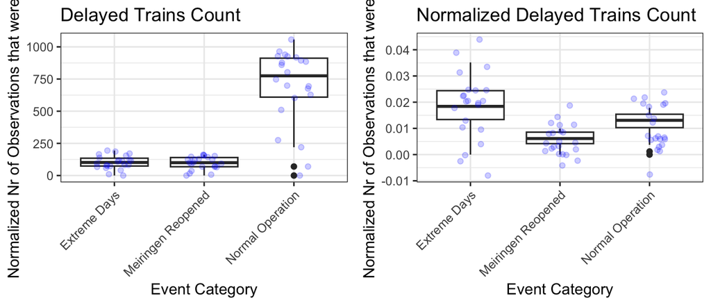

To statistically assess the differences observed in the boxplot, we conduct an ANOVA followed by multiple comparison testing.

- The ANOVA confirms that there is a statistically significant difference between at least one of the three day categories.
- The multiple comparison test further reveals that all pairwise differences between the categories are statistically significant.

This indicates that event_category is a strong predictor and will be considered for inclusion in the modeling process.

```
               Df   Sum Sq   Mean Sq F value   Pr(>F)
event_category  2 0.001753 0.0008766   20.86 1.12e-07 ***
Residuals      63 0.002647 0.0000420
---
Signif. codes:  0 '***' 0.001 '**' 0.01 '*' 0.05 '.' 0.1 ' ' 1
```

```
     Simultaneous Tests for General Linear Hypotheses

Multiple Comparisons of Means: Tukey Contrasts


Fit: aov(formula = Count_Delayed_Norm ~ event_category, data = d.poisson.agg.day.dc)

Linear Hypotheses:
                                            Estimate Std. Error t value
Meiringen Reopened - Extreme Days == 0     -0.012604   0.001954  -6.449
Normal Operation - Extreme Days == 0       -0.006917   0.001954  -3.539
Normal Operation - Meiringen Reopened == 0  0.005687   0.001954   2.910
                                           Pr(>|t|)
Meiringen Reopened - Extreme Days == 0      < 1e-04 ***
Normal Operation - Extreme Days == 0        0.00213 **
Normal Operation - Meiringen Reopened == 0  0.01359 *
---
Signif. codes:  0 '***' 0.001 '**' 0.01 '*' 0.05 '.' 0.1 ' ' 1
(Adjusted p values reported -- single-step method)
```

### Temperature and Precipitation

Weather data may also influence train delays. In the dataset, daily weather variables such as precipitation and temperature are available for the Lucerne region. However, initial visualizations do not reveal any clear correlation between weather conditions and the number of delayed trains. Despite this, the weather variables are still included in the GLM to assess whether they contribute any predictive value that is not immediately apparent from the visual analysis.

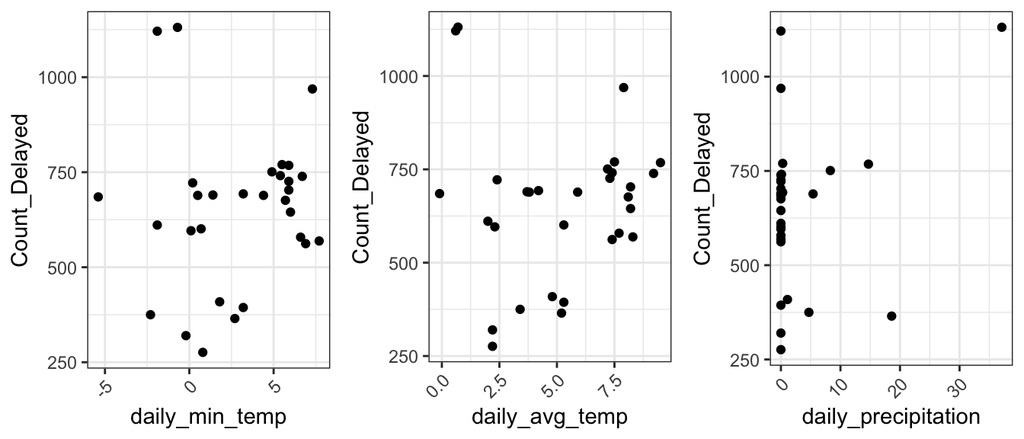

## Building the GLM model

“Prior to building the model, 80% of the available data was randomly selected for training. For simplicity, the training data was chosen without stratification.

To simplify model interpretation, the reference level for both Event Category and Operation Category was set to “Normal operation”. This choice facilitates clearer comparisons and makes the interpretation of model coefficients more intuitive.

```r
# Prepare Reference Level to Normal Operation
trainData$event_category <- as.factor(trainData$event_category) %>%
  relevel(ref = "Normal Operation")
trainData$operation_category <- as.factor(trainData$operation_category) %>%
  relevel(ref = "Normal Operation")
```

The initial GLM includes the promising predictors: Operation Category and Event Category. Additionally, it also includes weather-related predictors, which, though not particularly promising, are included to explore their impact. These include Daily Min. Temperature, which is more relevant than the average temperature as extreme temperatures may cause technical defects, and Daily Precipitation.

Looking at the summary, it becomes clear that the weather data do not significantly contribute to the model.

*Note*: The GLM was run with the “quasipoisson” family due to overdispersion. If the model were run with the “poisson” family, the predictor “daily_min_temp” and “daily_precipitation” would appear significant, which is clearly incorrect.

```r
glm <- glm(Count_Delayed ~ operation_category + event_category + daily_min_temp + daily_precipitation,
family = "quasipoisson", data = trainData)

summary(glm)
```

```
Call:
glm(formula = Count_Delayed ~ operation_category + event_category +
    daily_min_temp + daily_precipitation, family = "quasipoisson",
    data = trainData)

Coefficients:
                                  Estimate Std. Error t value Pr(>|t|)
(Intercept)                       3.267562   0.038505  84.860  < 2e-16 ***
operation_categoryLow Operation  -1.635018   0.118009 -13.855  < 2e-16 ***
operation_categoryRush Hour       0.435519   0.035864  12.144  < 2e-16 ***
event_categoryExtreme Days        0.513851   0.077597   6.622 8.83e-11 ***
event_categoryMeiringen Reopened -0.659573   0.059305 -11.122  < 2e-16 ***
daily_min_temp                    0.011188   0.006005   1.863    0.063 .
daily_precipitation               0.002738   0.002362   1.159    0.247
---
Signif. codes:  0 '***' 0.001 '**' 0.01 '*' 0.05 '.' 0.1 ' ' 1

(Dispersion parameter for quasipoisson family taken to be 4.559697)

    Null deviance: 6887.5  on 527  degrees of freedom
Residual deviance: 2388.5  on 521  degrees of freedom
AIC: NA

Number of Fisher Scoring iterations: 6
```

What is evident from the summary is also confirmed by the Drop 1 analysis:

- Operation Category significantly increases the deviance, indicating its importance as a predictor.
- The same applies to Event Category, which also contributes meaningfully to the model.
- In contrast, the weather data does not appear to be useful predictors, as removing them does not substantially affect the deviance.

```r
drop1(glm, Test = "F")
```

```
Single term deletions

Model:
Count_Delayed ~ operation_category + event_category + daily_min_temp +
    daily_precipitation
                    Df Deviance
<none>                   2388.5
operation_category   2   5436.8
event_category       2   3537.6
daily_min_temp       1   2404.5
daily_precipitation  1   2394.6
```

*Therefore for the final model the weather data is dropped!*

```r
glm <- glm(Count_Delayed ~ operation_category + event_category,
family = "quasipoisson", data = trainData)
```

```r
glm <- glm(Count_Delayed ~ operation_category + event_category,
family = "quasipoisson", data = trainData)

summary(glm)
```

```
Call:
glm(formula = Count_Delayed ~ operation_category + event_category,
    family = "quasipoisson", data = trainData)

Coefficients:
                                 Estimate Std. Error t value Pr(>|t|)
(Intercept)                       3.31586    0.03020 109.803   <2e-16 ***
operation_categoryLow Operation  -1.63259    0.11870 -13.753   <2e-16 ***
operation_categoryRush Hour       0.43698    0.03608  12.110   <2e-16 ***
event_categoryExtreme Days        0.49912    0.05590   8.928   <2e-16 ***
event_categoryMeiringen Reopened -0.68605    0.05631 -12.184   <2e-16 ***
---
Signif. codes:  0 '***' 0.001 '**' 0.01 '*' 0.05 '.' 0.1 ' ' 1

(Dispersion parameter for quasipoisson family taken to be 4.617011)

    Null deviance: 6887.5  on 527  degrees of freedom
Residual deviance: 2412.9  on 523  degrees of freedom
AIC: NA

Number of Fisher Scoring iterations: 6
```

```r
exp(coef(glm))
```

```
                     (Intercept)  operation_categoryLow Operation
                      27.5461579                        0.1954231
     operation_categoryRush Hour       event_categoryExtreme Days
                       1.5480177                        1.6472706
event_categoryMeiringen Reopened
                       0.5035634
```

## Results

The model provides the following results:

- Intercept: On a normal operation day and during normal operation hours, the average number of delayed observations is 28 per hour.
- Changing the operation to “Low Operation” (while keeping all other factors constant) results in an average of 28 * 0.2 ≈ 6 delayed observations per hour.
- Changing the operation to “Rush Hour” (while keeping all other factors constant) results in an average of 28 * 1.5 = 42 delayed observations per hour.
- Changing the event to “Extreme Days” (while keeping all other factors constant) results in an average of 28 * 1.6 = 45 delayed observations per hour.
- Changing the event to “Meiringen Reopened” (while keeping all other factors constant) results in an average of 28 * 0.5 = 14 delayed observations per hour.

## Validation

The remaining 132 observations were used to evaluate the model’s performance. The plot below highlights considerable uncertainty in the predictions, especially for larger count values, where the model tends to significantly underestimate the actual counts. This may be attributed to the limited number of delay instances in the dataset.

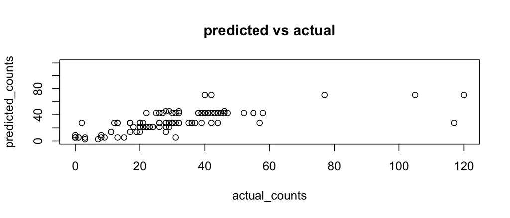

## Conclusion

The model allows for rough predicting the expected number of delayed trains per hour across different event and operational categories. However, it’s important to keep in mind that the number of delayed trains per category is correlated with the total number of trains operating during that category. Naturally, the more trains are in operation, the higher the likelihood of delays.

# Support Vector Machine Model

In modern transportation systems, data incompleteness remains a persistent challenge. Within Zentralbahn’s operational datasets, one recurring issue is the absence of station names (HALTESTELLEN_NAME), which impairs downstream analysis and monitoring.

As part of the broader data-driven initiative to improve performance and data quality—particularly in light of the November 2024 disruptions—this chapter focuses on addressing missing station data through predictive modeling.

Specifically, we propose using Support Vector Machines (SVM), a well-established classification algorithm, to infer missing station names based on contextual features such as timestamps, weekday indicators, and route metadata. This modeling task is framed as a multi-class classification problem, aiming to recover labels for incomplete entries.

Our objective is to demonstrate a scalable methodology that not only enhances the quality of the November 2024 dataset but also provides a template for correcting similar issues in historical records, ultimately supporting SBB’s long-term data reliability goals.

## Data Import and Initial Exploration

The dataset, sourced from Zentralbahn operations, includes variables such as station names, arrival and departure times, line identifiers, and travel routes. These serve as potential predictors in our modeling framework.

Initial exploratory analysis highlighted a large number of unique station labels and several variables with inconsistent or missing values. A summary of categorical distributions and missingness was conducted to determine preprocessing steps.

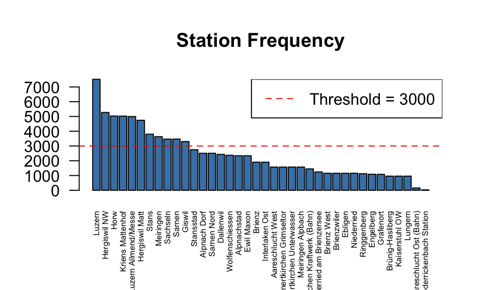

```r
# Visualize station frequency to identify high-volume locations
library(ggplot2)
station_counts <- sort(table(d.trains$HALTESTELLEN_NAME), decreasing = TRUE)

# Plot bar chart of station frequency with a threshold line at 3000
barplot(station_counts, las = 2, cex.names = 0.5, main = "Station Frequency", col = "steelblue")
abline(h = 3000, col = "red", lty = 2)
legend("topright", legend = "Threshold = 3000", col = "red", lty = 2)
```

To mitigate model complexity and class imbalance, we filtered the dataset to retain only stations with more than 3,000 observations.

## Feature Engineering

To prepare the dataset for SVM, we performed several transformations. Given that SVMs are sensitive to feature scale and representation, our goal was to create features that support margin-based classification.

- **Temporal Features**: We parsed date and time variables into structured formats.
- **Minutes to Midnight**: This numeric representation provides a linear scale for time, crucial for SVM performance.
- **Weekday Extraction**: Encoded as a categorical variable, this adds temporal context.
- **Route Encoding**: We constructed a new categorical feature by concatenating the departure `START` and destination `ZIEL` station names (e.g., “Engelberg_Luzern”). This captures directional travel information and enables the model to recognize station-pair patterns.

## Binary Classification Reformulation

### Why We Switched to Binary Classification

We defined a binary classification label that assigns the value `Luzern` when the station name matches Luzern, and `Other` otherwise.

Our initial plan involved a multi-class SVM model to predict the full set of station names. However, this approach encountered multiple challenges:

- Severe class imbalance, with many underrepresented stations.
- Long training times due to the large feature space and high cardinality of the response.
- Low predictive accuracy and inability to generalize for minority classes.
- Too many overlapping feature distributions for distinct stations.

To address these issues, we refocused the task into a binary classification problem, predicting whether a station is Luzern or Other. Luzern was chosen due to its high frequency, which provides a solid training base.

### Creating the Balanced Dataset

To create a balanced dataset for binary classification, we defined a new target variable that distinguishes between the station Luzern and all other stations. Given the class imbalance—where non-Luzern stations are more frequent—we applied a downsampling strategy to ensure an equal number of observations for both classes. Specifically, we randomly sampled the majority class (Other) to match the number of Luzern cases, thereby preventing the model from being biased toward the more common class. The resulting dataset was then shuffled to eliminate any ordering effects before model training.

### Encoding, Scaling and Dataset Assembly

```r
# One-hot encode categorical variables and scale time-based feature
library(caret)
dummy_vars_bin <- dummyVars(~ WOCHENTAG + LINIEN_TEXT + route, data = d.binary)
encoded_bin <- predict(dummy_vars_bin, newdata = d.binary)
scaled_minutes_bin <- scale(d.binary$minutes_to_midnight)

# Combine all features into final dataset for SVM training
d.binary.final <- data.frame(
  binary_station = d.binary$binary_station,
  minutes_to_midnight = as.numeric(scaled_minutes_bin),
  encoded_bin
)
```

Although the current model uses downsampling to balance the classes, alternative strategies such as class weighting or synthetic oversampling (e.g., SMOTE) could be considered in future work. These approaches preserve more training data and may lead to improved generalization, particularly in scenarios with evolving class distributions or in applications involving rare station patterns.

The final dataset was prepared with balanced classes and scaled numerical features, enabling effective SVM training. In the next section, we evaluate model performance using cross-validation to ensure robustness and generalizability.

## SVM Model 1: Linear Kernel

### Cross-Validation Strategy

To ensure robust model performance and mitigate overfitting, we implemented a **5-fold cross-validation scheme** using the caret package’s trainControl function. The cross-validation procedure was configured to report ROC-based performance metrics, reflecting our emphasis on distinguishing between Luzern and other stations. Class probabilities were enabled to support ROC computation, and verbose output was used to monitor progress across folds. A fixed random seed ensured reproducibility. This setup provided a stable evaluation framework to tune the SVM hyperparameters and compare model variants consistently.

### Train Linear SVM

We trained a linear classifier using the `caret` package, with ROC as the optimization metric. Parallel processing was employed to accelerate computation, utilizing all but one of the available cores. A grid search over three regularization values (C = 0.01, 0.1, 1) was conducted to identify the best-performing model. Training was guided by the previously defined cross-validation strategy, ensuring consistent evaluation across hyperparameter settings. The linear kernel was chosen for its efficiency and interpretability, aligning with the practical needs of large-scale deployment.

```r
# Train linear SVM using caret with parallel processing
library(doParallel)
cl <- makePSOCKcluster(parallel::detectCores() - 1)
registerDoParallel(cl)

svm_linear_bin <- train(
  binary_station ~ .,
  data = d.binary.final,
  method = "svmLinear",
  trControl = control,
  tuneGrid = expand.grid(C = c(0.01, 0.1, 1)),
  metric = "ROC"
)

stopCluster(cl)
```

### Evaluate Model Performance

To assess classification effectiveness, we evaluated the model using both threshold-independent and threshold-dependent metrics. A ROC curve was generated using predicted probabilities to visualize the trade-off between true and false positive rates across different thresholds. This allows for an overall understanding of the model’s discriminative capacity. In addition, we computed a confusion matrix to summarize classification outcomes under the default threshold. Key metrics including precision, recall, and F1 score were calculated to quantify how well the model identified Luzern instances relative to all predictions made. These evaluations offer a balanced view of model performance, particularly under class imbalance.

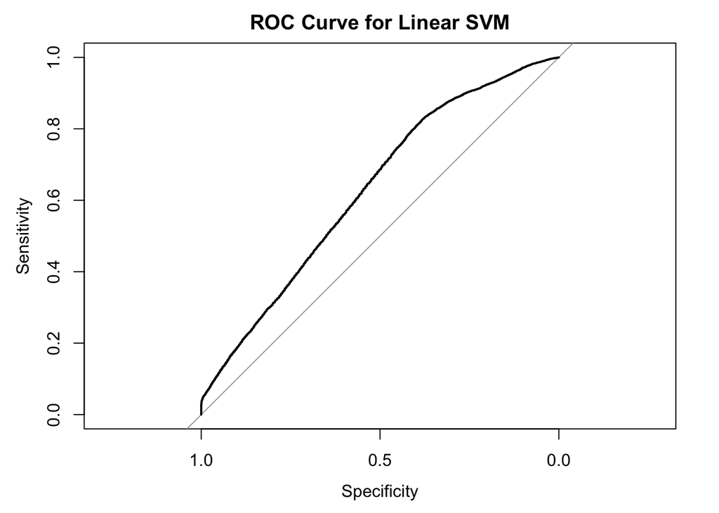

```
Confusion Matrix and Statistics

          Reference
Prediction Luzern Other
    Luzern   2809  1254
    Other    4710  6265

               Accuracy : 0.6034
                 95% CI : (0.5955, 0.6112)
    No Information Rate : 0.5
    P-Value [Acc > NIR] : < 2.2e-16

                  Kappa : 0.2068

 Mcnemar's Test P-Value : < 2.2e-16

            Sensitivity : 0.3736
            Specificity : 0.8332
         Pos Pred Value : 0.6914
         Neg Pred Value : 0.5708
             Prevalence : 0.5000
         Detection Rate : 0.1868
   Detection Prevalence : 0.2702
      Balanced Accuracy : 0.6034

       'Positive' Class : Luzern
```

```
  C
3 1
```

### Model Evaluation Results

The linear SVM model achieved an accuracy of **60.3%** on the balanced training data, with **C = 1** selected by cross-validation as the optimal regularization parameter. The ROC curve (Figure above) suggests the classifier performs only modestly better than random guessing (AUC ≈ 0.6), indicating limited discriminative power.

Confusion Matrix Summary:

- **Precision (Luzern)**: 0.691
- **Recall (Luzern)**: 0.374
- **F1 Score (Luzern)**: 0.485
- **Balanced Accuracy**: 0.603

The model is conservative: when it predicts Luzern it is right in about 69% of cases, but it only finds about 37% of the actual Luzern observations and assigns most of them to Other. This misclassification behavior is expected given the overlapping feature distributions of the stations.

### Feature Importance

These findings suggest that the model’s classification is primarily driven by spatial patterns encoded in the route and line metadata, with some influence from temporal structure.

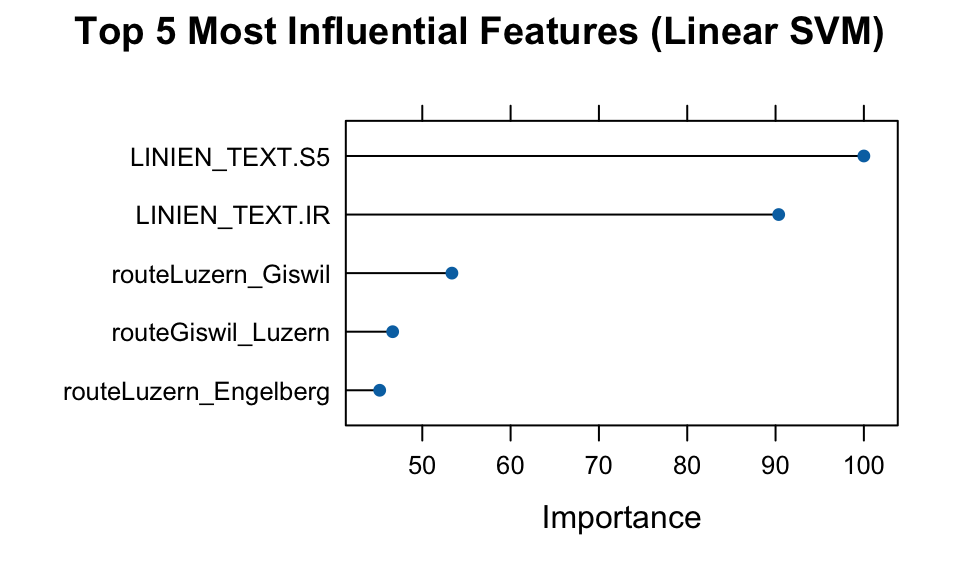

While the linear kernel offered interpretability and computational efficiency, its performance was constrained by overlapping feature distributions and the inherent limitations of linear separability. To address these constraints, we next explore a non-linear variant using the radial basis function (RBF) kernel.

## SVM Model 2: Radial Kernel

To evaluate the impact of using a non-linear decision boundary, we trained an SVM model with a radial basis function (RBF) kernel using the same feature set and cross-validation strategy as the linear model. Similar to the previous setup, parallel processing was enabled to expedite computation. A hyperparameter grid search was conducted over three cost values (C = 0.01, 0.1, 1) while fixing the RBF kernel width parameter (`sigma`) at 0.01. This controlled setup allowed us to isolate the influence of the kernel type while holding other training conditions constant. The model was evaluated using ROC as the primary performance metric, consistent with the linear SVM training process.

```
Confusion Matrix and Statistics

          Reference
Prediction Luzern Other
    Luzern   2818  1232
    Other    4701  6287

               Accuracy : 0.6055
                 95% CI : (0.5976, 0.6133)
    No Information Rate : 0.5
    P-Value [Acc > NIR] : < 2.2e-16

                  Kappa : 0.2109

 Mcnemar's Test P-Value : < 2.2e-16

            Sensitivity : 0.3748
            Specificity : 0.8361
         Pos Pred Value : 0.6958
         Neg Pred Value : 0.5722
             Prevalence : 0.5000
         Detection Rate : 0.1874
   Detection Prevalence : 0.2693
      Balanced Accuracy : 0.6055

       'Positive' Class : Luzern
```

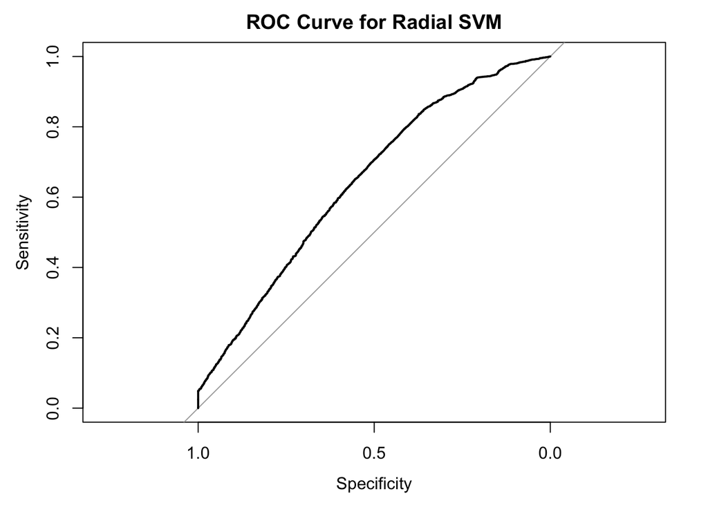

```
  sigma C
3  0.01 1
```

### Model Evaluation Results

The confusion matrix shows nearly the same error profile as the linear version:

- **Precision (Luzern): 0.696**
- **Recall (Luzern): 0.375**
- **F1 Score (Luzern): 0.487**
- **Balanced Accuracy: 0.606**

Precision, recall and balanced accuracy are almost identical to the linear model, so the non-linear decision boundary adds little under the current feature set. Given the added computational cost and limited performance gain, the RBF kernel offers only marginal benefit under the current feature set.

## Model Comparison

To systematically compare the linear and radial SVM models, we summarized their performance across several classification metrics: AUC, precision, recall, and F1 score. Both models were evaluated on the same dataset using the same cross-validation strategy to ensure a fair comparison. While the radial SVM achieved slightly higher values across all metrics — including a marginal AUC increase from 0.629 to 0.644 — both models exhibited limited overall discriminative power. The ROC curves show substantial overlap, with the radial model offering only a slight advantage in sensitivity at certain thresholds. Given this modest performance gain and the radial model’s higher computational cost, the linear SVM remains the more practical choice for time-sensitive or large-scale applications.

| Model | AUC | Precision | Recall | F1_Score |
| --- | --- | --- | --- | --- |
| Linear SVM | 0.629 | 0.691 | 0.374 | 0.485 |
| Radial SVM | 0.644 | 0.696 | 0.375 | 0.487 |

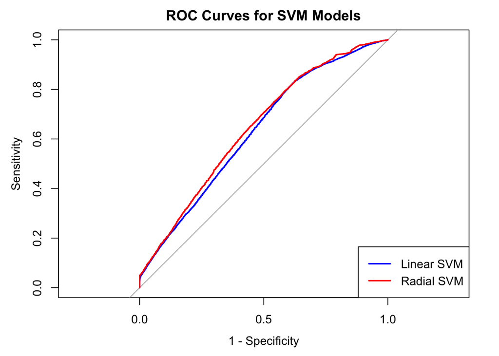

## Discussion

While this chapter focuses on classifying Luzern versus all other stations, the binary setup serves as a scalable case study. Luzern was chosen for its frequency and stability in the data, but the approach generalizes to other stations or multi-class scenarios via one-vs-rest classifiers—paving the way for broader imputation strategies across Zentralbahn’s records.

The linear SVM yielded moderate performance, with reasonable precision but low recall—reflecting overlapping feature distributions and limited class separability. The near-diagonal ROC curve underscores the model’s constrained discriminative power.

Compared to the linear kernel, the radial SVM offered marginal gains in AUC and F1 score but incurred significantly higher computation times. These modest improvements did not outweigh the radial model’s cost, especially in real-time or large-scale settings where the linear SVM remains preferable for its simplicity and efficiency.

Several challenges persist: limited feature variability across stations, weak temporal signals, and noise introduced by high-cardinality variables like route names. Addressing these may involve richer feature engineering, applying non-linear models to curated subsets, or leveraging ensemble methods to reduce variance and overfitting.

## Conclusion

This analysis demonstrated how Support Vector Machines can be used to impute missing station names for Zentralbahn. Initially formulated as a multi-class problem, the task was reformulated as a binary classification due to high class imbalance, overlapping distributions, and excessive runtime demands.

The linear SVM model achieved a balanced accuracy of 60.3% and a precision of 69% for predicting Luzern. Although recall was low, observations it flags as Luzern are mostly correct, so its predictions could serve as candidates that are then verified through business logic or downstream systems.

A comparison with a radial SVM showed slight metric improvements, but at the expense of computational cost. For production scenarios where interpretability and efficiency are paramount, the linear model offers a practical trade-off.

In summary, even a simple linear SVM—when paired with balanced training data and thoughtful feature engineering—can provide actionable insights for enriching transport data in real-world operational settings.

# Use of Generative AI

ChatGPT can be a valuable tool for various aspects of programming, particularly for detecting syntax errors and generating initial plots quickly. It provides immediate feedback, making it easier for users to identify issues and visually present their data. This speed and convenience can help jump-start the coding process, especially for beginners or when exploring new concepts.

However, there are limitations to relying solely on ChatGPT for more complex tasks. While it can help create basic plots, developing more specific or tailored visualizations often leads users down a “rabbit hole,” where time is spent refining the plot rather than focusing on the underlying analysis. Additionally, implementing modularity in code is challenging when using ChatGPT. It requires a deeper understanding of programming concepts to ensure code is reusable, maintainable, and efficient, which cannot always be achieved through AI-generated solutions alone.

Another significant concern is that the code generated by ChatGPT is often done quickly, but it may lack proper documentation and clarity. Without adequate comments and explanations, the code can be difficult to read and understand, posing challenges for collaboration or future revisions. Furthermore, ChatGPT sometimes generates overly complex solutions when a simpler, more efficient approach could be used, which could be easily implemented with just a few lines of code if the programmer has a solid grasp of the task at hand.

As data scientists, it is essential not only to understand the technical aspects of coding but also to gain a deep understanding of the data itself. Data analysis is a creative process that involves continuous iteration, exploration, and insight. To arrive at meaningful conclusions, data scientists must engage with domain experts and other stakeholders throughout the analysis process. This collaboration helps ensure that the results are accurate, relevant, and actionable, ultimately leading to well-informed decisions.

In conclusion, while ChatGPT offers valuable assistance in coding, especially for quick debugging and basic tasks, it is important for users to ensure they understand their code thoroughly and the data they are working with. Achieving effective modularity, clarity, and efficiency requires a combination of technical expertise and creativity, with ongoing collaboration, to ensure the success of data analysis projects

# Conclusion

This report set out to investigate the operational disruptions experienced by Zentralbahn in November 2024, with a focus on uncovering the root causes of winter-related performance bottlenecks and improving data reliability through predictive modeling. Through a structured exploration of various machine learning methods, the analysis identified critical patterns influencing both delay propagation and data integrity.

Initial modeling using artificial neural networks confirmed that the dataset contained meaningful signals, even without prior domain knowledge. This served as a foundation for more interpretable approaches. Generalized Additive Models demonstrated that while temperature and precipitation exhibit statistically significant relationships with delay metrics, their explanatory power remains limited. In contrast, operational and temporal factors—such as specific train lines or time of day have a more pronounced influence.

Generalized Linear Models, particularly in the binomial and Poisson frameworks, highlighted the importance of line-specific characteristics and contextual variables like rush-hour periods. Notably, the reopening of the Meiringen–Interlaken line emerged as a key inflection point, significantly altering delay dynamics. Additionally, Luzern’s function as a stabilizing hub was consistently associated with reduced delay propagation, underscoring the strategic importance of hub infrastructure.

Beyond performance modeling, the application of Support Vector Machines addressed a parallel objective: enhancing data quality. By formulating the recovery of missing station names as a classification problem, a methodological basis was established for scalable data imputation. Although performance was modest, the approach contributes to broader efforts to restore and maintain the integrity of historical transport records.

The findings underscore the multifactorial nature of railway delays, wherein environmental conditions act as secondary factors to more decisive operational and infrastructural elements. While current models offer valuable insights, a substantial portion of variability remains unexplained. This suggests the potential benefit of integrating additional data sources—such as real-time operational logs, staffing levels, or infrastructure status—into future modeling efforts.

In conclusion, the analysis not only confirms several hypotheses regarding winter bottlenecks but also provides a data-driven framework for identifying vulnerabilities and guiding operational decisions. By transforming raw transport and weather data into actionable insights, this work contributes to a more resilient and efficient transportation system of the Zentralbahn.